# MATHEMATICAL MODELLING FOR MACHINE LEARNING PERSONAL PROJECT: BINARY CLASSIFICATION

In this notebook I will construct a model which aims to predict a binary label (0,1) for a dataset with 25 generic numerical features and 2 generic categorical features. My task will be to compare the performance of a linear Support Vector Machine (for example sklearn.svm.LinearSVC or sklearn.svm.SVC with a linear kernel) with that of Logistic Regression (sklearn.linear_model.LogisticRegression). The dataset is a dataframe of 1400 rows and 27 columns. My notebook will follow this structure:

- EDA (Exploratory Data Analysis)
- Data Preprocessing
- Model Selection
  - Extra Models
- Hyperparameter Tuning
- Model Fitting
- Shap model visualization
- Final Remarks and Limitations

I will include at the start of each section a markdown written by ChatGPT saying what it would have done in my place and then briefly commenting it.

```python
import numpy as np
import matplotlib.pyplot as plt
import pandas as pd

from sklearn.linear_model import LogisticRegression
from scipy.stats import loguniform
from sklearn.model_selection import train_test_split, cross_val_score, RandomizedSearchCV, StratifiedKFold
from sklearn.preprocessing import StandardScaler, OneHotEncoder, PolynomialFeatures
from sklearn.metrics import ConfusionMatrixDisplay, balanced_accuracy_score, roc_auc_score, RocCurveDisplay
from sklearn.ensemble import RandomForestClassifier
from sklearn.pipeline import Pipeline
from sklearn.compose import ColumnTransformer
from sklearn.feature_selection import mutual_info_classif
from sklearn.svm import LinearSVC, SVC
from sklearn.decomposition import PCA
from sklearn.manifold import TSNE
from sklearn.impute import SimpleImputer

random_state = 44
```

```python
train_data = pd.read_csv('mldata_0003314701.csv')
```

## EXPLORATORY DATA ANALYSIS

Firstly, I separate the training data into x_train and y_train, with x being the features and y the target (namely the labels). I also create the variables num_cols and cat_cols to separate the numerical features columns and the categorical features ones. In this section i will include some plots which are going to be useful for my preprocessing pipeline:

```python
x_train = train_data.drop(['label', 'id'], axis=1)
y_train = train_data['label'].squeeze()
cat_cols = x_train.select_dtypes(include=['object']).columns
num_cols = x_train.select_dtypes(include=['int64', 'float64']).columns
```

|  | feature_1 | feature_2 | feature_3 | feature_4 | feature_5 | feature_6 | feature_7 | feature_8 | feature_9 | feature_10 | ... | feature_16 | feature_17 | feature_18 | feature_19 | feature_20 | feature_21 | feature_22 | feature_23 | feature_24 | feature_25 |
| --- | --- | --- | --- | --- | --- | --- | --- | --- | --- | --- | --- | --- | --- | --- | --- | --- | --- | --- | --- | --- | --- |
| count | 1324.000000 | 1400.000000 | 1400.000000 | 1290.000000 | 1400.000000 | 1272.000000 | 1400.000000 | 1260.000000 | 1400.000000 | 1400.000000 | ... | 1316.000000 | 1306.000000 | 1400.000000 | 1312.000000 | 1342.000000 | 1400.000000 | 1309.000000 | 1400.000000 | 1400.000000 | 1315.000000 |
| mean | 1.280572 | 3.061295 | -0.259094 | 3.662490 | 1.403695 | -1.823071 | -0.969806 | 1.709555 | 0.413749 | -2.178013 | ... | -3.509062 | 2.030788 | 1.458905 | 0.561437 | 0.575931 | -0.494818 | 0.872631 | -2.886515 | -0.212214 | -4.326303 |
| std | 10.318960 | 24.949568 | 4.911310 | 7.513987 | 6.804337 | 7.508633 | 7.380553 | 18.228202 | 8.709712 | 12.725274 | ... | 8.744610 | 9.226358 | 5.623966 | 7.778429 | 7.227051 | 11.393063 | 10.812062 | 11.141964 | 6.062665 | 11.433647 |
| min | -30.508517 | -76.203409 | -17.189057 | -30.210852 | -19.592124 | -24.373725 | -22.130783 | -54.058904 | -24.637434 | -43.833694 | ... | -31.223907 | -36.635428 | -20.212266 | -29.967826 | -26.798941 | -36.425734 | -32.806263 | -42.380755 | -23.532181 | -51.210889 |
| 25% | -5.904726 | -13.797621 | -3.604747 | -0.589990 | -3.441849 | -7.268681 | -6.277317 | -10.985922 | -5.324901 | -10.770289 | ... | -9.269154 | -3.768653 | -2.145125 | -4.602609 | -4.316730 | -8.738989 | -6.452160 | -10.404548 | -4.000714 | -11.518598 |
| 50% | 0.818062 | 1.973863 | -0.455461 | 4.274168 | 1.125511 | -1.755153 | -1.683685 | 1.297096 | 0.407027 | -1.867301 | ... | -3.718918 | 2.421070 | 1.534192 | 0.640767 | 0.695492 | -0.407457 | 0.508560 | -3.047292 | -0.305927 | -5.035332 |
| 75% | 8.097738 | 18.796333 | 2.800158 | 8.650247 | 5.538092 | 3.189103 | 3.405127 | 13.777471 | 6.215567 | 6.706610 | ... | 2.296705 | 7.985229 | 5.031131 | 5.785431 | 5.558698 | 7.061550 | 7.545492 | 3.800959 | 3.753249 | 1.878069 |
| max | 38.369724 | 82.529503 | 20.923396 | 29.342364 | 28.169022 | 24.343806 | 26.752584 | 70.560825 | 26.422567 | 35.859147 | ... | 26.155767 | 30.699296 | 17.840814 | 23.329130 | 23.317877 | 31.643639 | 36.826546 | 43.104067 | 26.251349 | 54.421904 |

8 rows × 25 columns

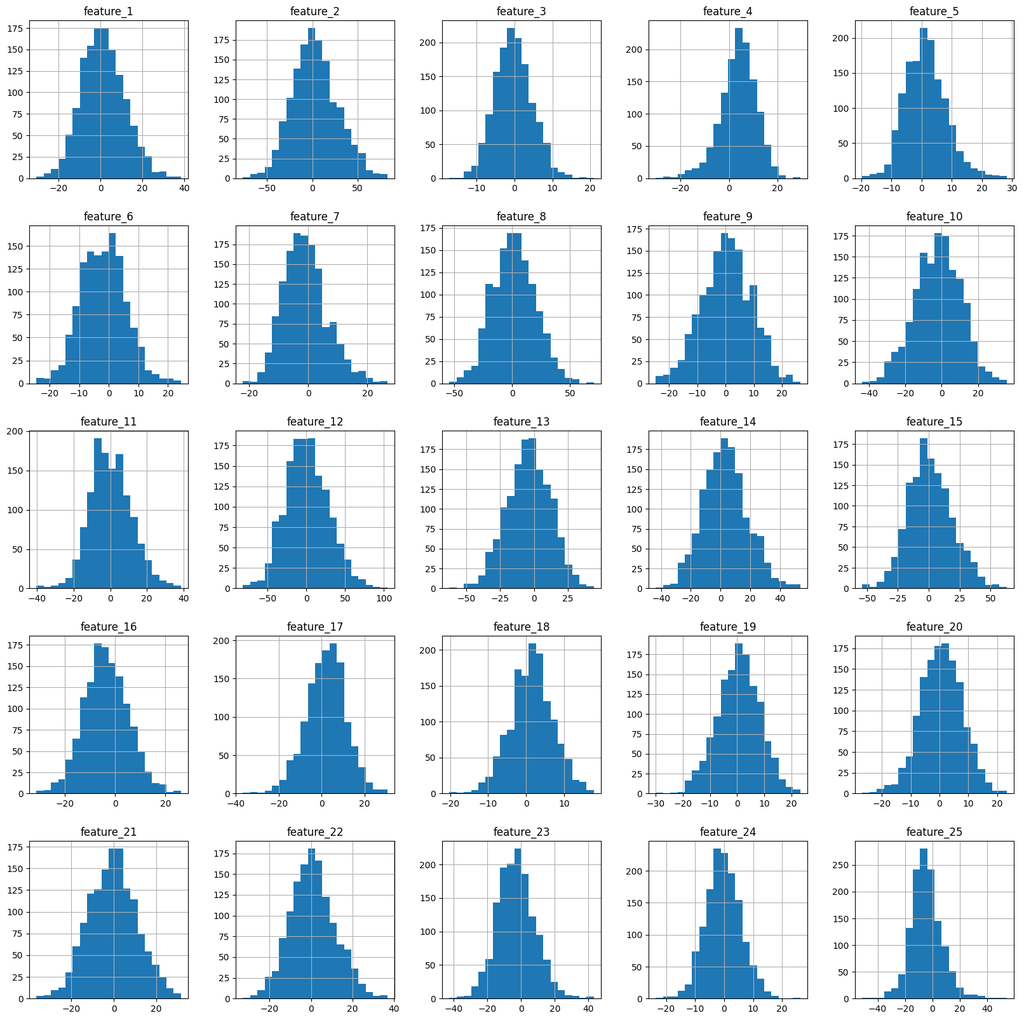

```python
display(x_train.describe())
x_train.hist(figsize=(20, 20), column=num_cols, bins=20)
plt.show()
```

We see that all the numerical features resemble a normal distribution and it is not possible to spot clear and visible outlier for outlier detection.

### MISSING VALUES

I now plot the missing values in descending order.

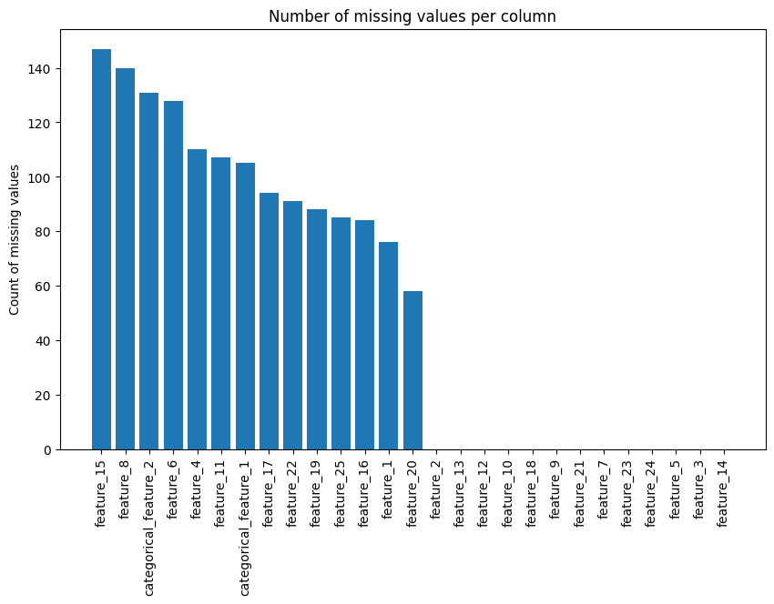

```python
missing_values = x_train.isnull().sum().sort_values(ascending=False)
plt.figure(figsize=(10, 6))
plt.bar(missing_values.index, missing_values.values)
plt.xticks(rotation=90)
plt.title('Number of missing values per column')
plt.ylabel('Count of missing values')
plt.show()
```

```python
missing_labels = y_train.isnull().sum()
print(f"Number of missing values in the target variable: {missing_labels}") # There are no missing values in the target variable, which is good for our analysis.\
```

```
Number of missing values in the target variable: 0
```

The number of missing values per feature is at most about 140 for x, which is approximately 10% of the 1,400 observations. This number is not extreme, so imputation is a reasonable approach rather than dropping rows or columns.

### MUTUAL INFORMATION

For a discrete random variable $X$ with support $\mathcal{X}$, and pmf $p(X)$, we define entropy and we denote by $H(X)$ the quantity:

$$ H(X) = \mathbb{E}[I(p(X))] = \sum_{x \in \mathcal{X}} p(x)\log_2\left(\frac{1}{p(x)}\right) $$

for $I(p(X))$ equal to:

$$ I(p(x)) = \log_2\left(\frac{1}{p(x)}\right) $$

and denoted as Information Content. We then define Conditional Entropy for two random variables $X$ and $Y$:

$$ H(X \mid Y) = \sum_{x \in \mathcal{X},\, y \in \mathcal{Y}} p(x,y)\log_2\left(\frac{1}{p(x \mid y)}\right) = \sum_{y \in \mathcal{Y}} H(X \mid Y = y)p(y). $$

and the joint entropy as:

$$ H(X,Y) = \sum_{x \in \mathcal{X},\, y \in \mathcal{Y}} p(x,y)\log_2\left(\frac{1}{p(x,y)}\right) $$

Finally, the mutual information between $X$ and $Y$ is defined as:

$$ I(X;Y) = H(X) - H(X \mid Y) $$

Equivalently,

$$ I(X;Y) = H(X) + H(Y) - H(X,Y) $$

Mutual information measures how much knowing one variable reduces uncertainty about the other. In this project, I use it as an exploratory measure of how informative each feature is about the label.

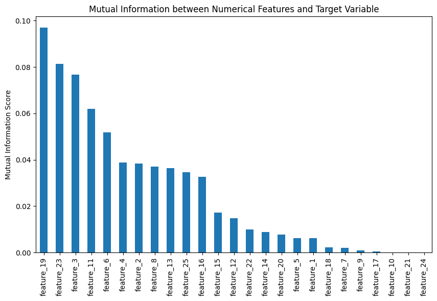

```python
mutual_info = pd.Series(mutual_info_classif(x_train[num_cols].fillna(x_train[num_cols].median()), y_train), index=num_cols)
mutual_info.sort_values(ascending=False, inplace=True)
plt.figure(figsize=(10, 6))
mutual_info.plot(kind='bar')
plt.title('Mutual Information between Numerical Features and Target Variable')
plt.ylabel('Mutual Information Score')
plt.show()
```

### CORRELATION

Next step is to include the correlation between the numerical columns

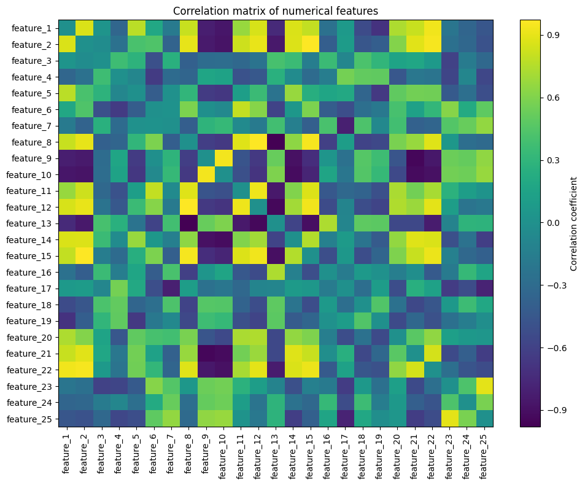

```python
corr_matrix = x_train[num_cols].corr()

for i in range(len(corr_matrix.columns)):
    corr_matrix.iloc[i, i] = 0   # we remove the diagonal because it is not informative as it is always 1

plt.figure(figsize=(10, 8))
plt.imshow(corr_matrix, aspect='auto')
plt.xticks(range(len(num_cols)), num_cols, rotation=90)
plt.yticks(range(len(num_cols)), num_cols)
plt.title('Correlation matrix of numerical features')
plt.colorbar(ticks=[-0.9, -0.6, -0.3, 0, 0.3, 0.6, 0.9], label='Correlation coefficient', orientation='vertical')
plt.tight_layout()
plt.show()
```

```python
corr_matrix.unstack().sort_values(ascending=False).drop_duplicates()
```

```
feature_15  feature_2     0.972095
feature_8   feature_12    0.966370
feature_22  feature_2     0.942970
feature_8   feature_15    0.941818
feature_10  feature_9     0.940595
                            ...
            feature_14   -0.914130
            feature_21   -0.923836
feature_12  feature_13   -0.940905
feature_21  feature_9    -0.947006
feature_8   feature_13   -0.979975
Length: 301, dtype: float64
```

I notice that i have several pairs of features that are highly correlated with each other: i now plot the scatter plot for the 5 most correlated (correlation coefficient close to 1) and the 5 most inversely correlated (correlation coefficient close to -1).

```python
corr_pairs = corr_matrix.unstack().sort_values(ascending=False)
corr_pairs = corr_pairs[corr_pairs != 0]
corr_pairs = corr_pairs[~corr_pairs.index.map(lambda x: tuple(sorted(x))).duplicated()]

top_positive = corr_pairs.head(5)
top_negative = corr_pairs.tail(5)

top_positive, top_negative
```

```
(feature_15  feature_2     0.972095
 feature_8   feature_12    0.966370
 feature_22  feature_2     0.942970
 feature_8   feature_15    0.941818
 feature_10  feature_9     0.940595
 dtype: float64,
 feature_10  feature_14   -0.914130
             feature_21   -0.923836
 feature_12  feature_13   -0.940905
 feature_21  feature_9    -0.947006
 feature_8   feature_13   -0.979975
 dtype: float64)
```

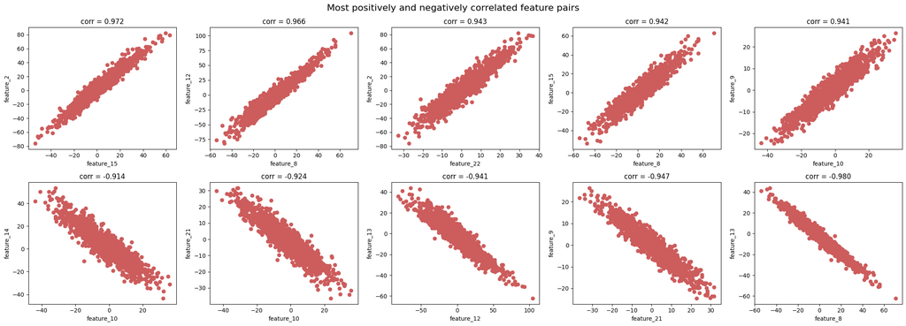

```python
pairs_to_plot = pd.concat([top_positive, top_negative])


fig, axes = plt.subplots(2, 5, figsize=(22, 8))
axes = axes.ravel()

for ax, ((feature_x, feature_y), corr_value) in zip(axes, pairs_to_plot.items()):
    ax.scatter(x_train[feature_x], x_train[feature_y], alpha=1, color = 'indianred')
    ax.set_xlabel(feature_x)
    ax.set_ylabel(feature_y)
    ax.set_title(f"corr = {corr_value:.3f}")

plt.suptitle("Most positively and negatively correlated feature pairs", fontsize=16)
plt.tight_layout()
plt.show()
```

These feature pairs show very strong positive or negative correlation. Hence it is reasonable to try PCA as a dimensionality-reduction experiment, for data visualization and an overall simpler model representation.

### LLM VERSION

The purpose of exploratory data analysis is to understand the dataset before modeling. I would start by plotting the distribution of the target variable. This gives an immediate view of whether one class dominates the other.

Next, I would examine missing values. Missingness can occur in both numerical and categorical variables, and the amount of missingness can influence the choice of preprocessing. For numerical features, median imputation is usually a strong default because it is robust to outliers. For categorical features, replacing missing values with the most frequent category is a simple and effective baseline.

I would then inspect the numerical features. This can include summary statistics, histograms, boxplots, and correlation analysis. Histograms help reveal skewed distributions, while boxplots can highlight outliers. A correlation heatmap can show whether some numerical features are strongly related to one another. Highly correlated variables are not necessarily a problem for tree-based models, but they can affect linear models and can also help explain model behavior.

For categorical features, I would check the number of unique categories and compare the category levels between the training set and the hidden test set. This is important because the hidden test set may contain categories that were not seen during training. To handle this safely, the one-hot encoder should be configured with handle_unknown="ignore" so that unseen categories do not cause prediction errors.

I would also examine the relationship between features and the target. For numerical variables, boxplots grouped by target class can show whether a feature separates the two classes. For categorical variables, target-rate plots can show whether some categories are associated with a higher probability of class 1.

The EDA stage should not be used to make final decisions based on the hidden test labels, because those labels are not available. It should mainly guide preprocessing choices, feature understanding, and sanity checks.

### COMMENTS

We agreed on the choices to make for EDA; it's not surprising as with a synthetic dataset my work is limited by my not knowledge of what the data signifies. Moreover ChatGPT 5.5 didn't check for Mutual Information or expanded the correlation analysis.

## PREPROCESSING

As we don't have any information on what the dataset represents, I opt for a standard preprocessing pipeline: filling NAs with the most frequent value for categorical columns and with the median for numerical columns. I chose these metric because they are the industry standard; in particular the median is a very robust solution handling well sets with outliers (I haven't spotted any but I still feel like it's the safer option). I then created Dummy Variables columns using `OneHotEncoder` for categorical variables and standardized the numerical ones.

```python
cat_preprocesser = Pipeline([
    ('imputer', SimpleImputer(strategy='most_frequent')),
    ('encoder', OneHotEncoder(handle_unknown='ignore'))
])

num_preprocesser = Pipeline([
    ('imputer', SimpleImputer(strategy='median')),
    ('scaler', StandardScaler())
])

preprocesser = ColumnTransformer([
    ('num', num_preprocesser, num_cols),
    ('cat', cat_preprocesser, cat_cols)
])
```

### LLM VERSION

The preprocessing must be designed separately for numerical and categorical features.

For numerical features, I would use median imputation followed by standard scaling. Median imputation handles missing values without being overly influenced by outliers. Standard scaling transforms each numerical feature so that it has approximately zero mean and unit variance. This is especially important for models such as logistic regression and support vector machines, because these models are sensitive to feature scale.

For categorical features, I would use most-frequent imputation followed by one-hot encoding. Most-frequent imputation replaces missing categorical values with the most common category in the training data. One-hot encoding then converts each category into binary indicator columns. This allows models to use categorical information without imposing an artificial numerical ordering.

These preprocessing steps should be placed inside a ColumnTransformer, which allows numerical and categorical columns to be processed differently. The ColumnTransformer should then be placed inside a Pipeline together with the machine learning model. This is one of the most important parts of the workflow because it prevents data leakage.

Data leakage would occur if imputation values, scaling parameters, or encoding decisions were learned from the full dataset before cross-validation. By putting preprocessing inside the pipeline, each cross-validation fold learns preprocessing only from the training portion of that fold.

### COMMENTS

Me and ChatGPT had the same ideas for preprocessing and I think that is also because of the anonimity of the data, meaning that we cannot put too much effort into cleaning the dataset. We both used pipelines which is the standard approach for preprocessing.

## PRINCIPAL COMPONENT ANALYSIS

Since we have many highly correlated dimensions, I try to reduce dimensionality of my dataset using `PCA` (Principal Component Analysis).

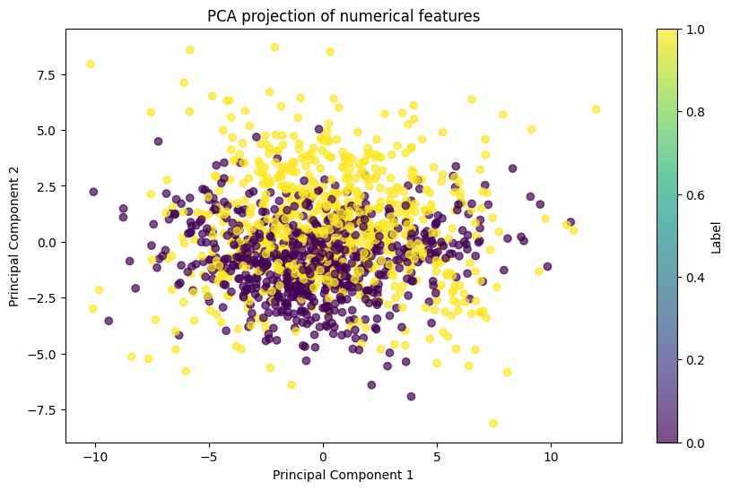

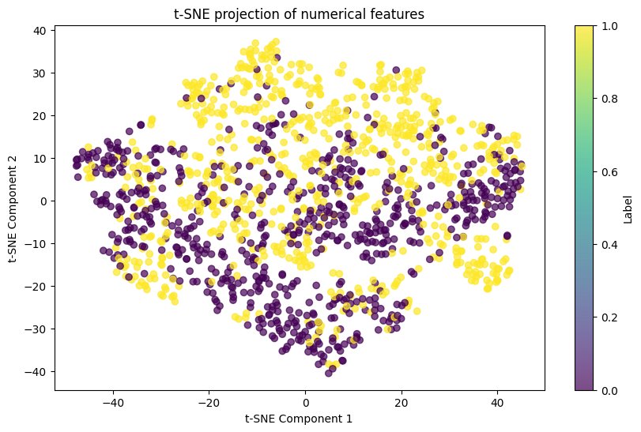

```python
pca_pipeline = Pipeline([
    ('imputer', SimpleImputer(strategy='median')),
    ('scaler', StandardScaler()),
    ('pca', PCA(n_components=0.95, random_state=random_state))
])

x_num_pca = pca_pipeline.fit_transform(x_train[num_cols])

pca_pipeline.named_steps['pca'].n_components_

plt.figure(figsize=(10, 6))
plt.scatter(x_num_pca[:, 0], x_num_pca[:, 1], c=y_train, cmap='viridis', alpha=0.7)
plt.colorbar(label='Label')
plt.title('PCA projection of numerical features')
plt.xlabel('Principal Component 1')
plt.ylabel('Principal Component 2')
plt.show()

tsne_pipeline = Pipeline([
    ('imputer', SimpleImputer(strategy='median')),
    ('scaler', StandardScaler()),
    ('tsne', TSNE(n_components=2, random_state=random_state))
])

x_num_tsne = tsne_pipeline.fit_transform(x_train[num_cols])
plt.figure(figsize=(10, 6))
plt.scatter(x_num_tsne[:, 0], x_num_tsne[:, 1], c=y_train, cmap='viridis', alpha=0.7)
plt.colorbar(label='Label')
plt.title('t-SNE projection of numerical features')
plt.xlabel('t-SNE Component 1')
plt.ylabel('t-SNE Component 2')
plt.show()
```

The `PCA` plot shows the first two principal components of the numeric features, colored by the label. The two classes overlap substantially, so a two-component linear projection does not reveal clear class separation. The `t-SNE` plot is a nonlinear two-dimensional visualization of the numeric feature space. Unlike `PCA`, `t-SNE` focuses on preserving local neighborhoods. The plot shows some local regions where one label is more common, but the two classes are still mixed overall. Therefore, these plots are useful for exploratory visualization, but final model choice should be based on cross-validation rather than visual separation. This provides evidence supporting the implementation of non-linear models that may be able to capture non-linear relations between features, such as `Catboost` or `RandomForest`.

### LLM VERSION

//

## MODEL SELECTION

I evaluate the following mandatory models:

- `Logistic Regression`
- `Support Vector Classifier with a linear kernel`
- `Linear Support Vector Classifier`

Logistic Regression is a linear classifier that models the probability of belonging to class 1:

$$ P(y = 1 \mid x) = \frac{1}{1 + e^{-(\beta_0 + \beta^T x)}} $$ The support vector classifiers also use a linear decision function: $$ f(x) = w^T x + b $$

where the predicted class depends on the sign of $f(x)$. The SVM objective tries to find a separating hyperplane with a large margin between the two classes. For both Logistic Regression and SVM models, the parameter $C$ controls the strength of regularization: smaller values of $C$ imply stronger regularization. Logistic Regression optimizes log loss, while the SVM models optimize hinge-based margin losses. In particular, `LinearSVC` uses squared hinge loss by default. I acknowledge that all three models use different loss functions, Logistic Regression optimizes log loss, while the SVM models optimize hinge-based margin losses. I do not change the loss functions as they are not relevant tuning dimensions (for two out of the three models the loss models is fixed). For the model selection I will rely on `balanced_accuracy` as a metric because it was the metric of the classification extra point challenge. The whole section of model selection is being done on a second split of the training data, to keep an "unseen" evaluation set to get a more realistic evaluation metric after fine tuning the parameters.

```python
models = {
    'LogisticRegression' : Pipeline([
        ('preprocesser', preprocesser),
        ('model', LogisticRegression(random_state=random_state, max_iter=20000))
    ]),
    'SVC' : Pipeline([
        ('preprocesser', preprocesser),
        ('model', SVC(kernel='linear', random_state=random_state))
    ]),
    'LinearSVC' : Pipeline([
        ('preprocesser', preprocesser),
        ('model', LinearSVC(random_state=random_state, max_iter=20000, dual=False))
    ])
}
x_tr, x_val, y_tr, y_val = train_test_split(x_train, y_train, test_size=0.2, random_state=random_state, stratify=y_train)
eval_set = (x_val, y_val) # I will keep this set aside for final evaluation model after tuning, it's not necessary for a dataset this small but it's good practice

cv = StratifiedKFold(n_splits=5, shuffle=True, random_state=random_state) # classes are balanced before the first split, so I can use stratified kfold to maintain the balance in each fold

y_tr.value_counts(normalize=True), y_val.value_counts(normalize=True) # I notice that the classes are still balanced, I still keep the StratifiedKFold as good practice
```

```
(label
 1    0.5125
 0    0.4875
 Name: proportion, dtype: float64,
 label
 1    0.510714
 0    0.489286
 Name: proportion, dtype: float64)
```

```python
print("\nCross-validation results:")
cross_val_scores = {}
for name, model in models.items():
    scores = cross_val_score(
        model,
        x_tr,
        y_tr,
        cv=cv,
        scoring='balanced_accuracy'
    )
    cross_val_scores[name] = scores.mean()
    print(f'{name} - Balanced Accuracy: {scores.mean():.4f}')
```

```
Cross-validation results:
LogisticRegression - Balanced Accuracy: 0.7873
SVC - Balanced Accuracy: 0.7872
LinearSVC - Balanced Accuracy: 0.7881
```

The obtained results signify that the Linear SVM models perform similarly, as does the Logistic Regression. My hypothesis is that the model struggles to identify non-linear relationships between the features, as highlighted by PCA, so I will try and add Polynomial Features to Logistic Regression

### POLYNOMIAL FEATURES

We now check whether my hypothesis is correct by running a Logistic Regression with the implementation of Polynomial Features.

```python
lognum_preprocesser = Pipeline([
    ('imputer', SimpleImputer(strategy='median')),
    ('scaler', StandardScaler()),
    ('poly', PolynomialFeatures(degree=2, interaction_only=True, include_bias=False)),
    ('secondscaler', StandardScaler())
])

logistic_preprocesser = ColumnTransformer([
    ('num', lognum_preprocesser, num_cols),
    ('cat', cat_preprocesser, cat_cols)
])

logregpol_model = Pipeline([
    ('preprocesser', logistic_preprocesser),
    ('model', LogisticRegression(random_state=random_state, max_iter=20000))
])


pol_score = cross_val_score(logregpol_model, x_tr, y_tr, cv=cv, scoring='balanced_accuracy').mean()
print(f'Logistic Regression with polynomial features - Balanced Accuracy: {pol_score:.4f}')
```

```
Logistic Regression with polynomial features - Balanced Accuracy: 0.8287
```

As predicted, the balanced accuracy score is higher.

### EXTRA MODELS

```python
try:
    import catboost
    print("catboost already installed")
except ImportError:
    %pip install catboost

from catboost import CatBoostClassifier
```

```
catboost already installed
```

As mentioned above, I will include two Tree-based models which should have better performance with a dataset of this structure.

```python
rnd_forest = Pipeline([
    ('preprocesser', preprocesser),
    ('model', RandomForestClassifier(random_state=random_state))
])

catboost_model = Pipeline([
    ('preprocesser', preprocesser),
    ('model', CatBoostClassifier(random_state=random_state, verbose=10, iterations = 100))
])

rnd_forest_scores = cross_val_score(
    rnd_forest,
    x_tr,
    y_tr,
    cv=cv,
    scoring='balanced_accuracy'
)

catboost_scores = cross_val_score(
    catboost_model,
    x_tr,
    y_tr,
    cv=cv,
    scoring='balanced_accuracy'
)

print(f'Random Forest - Balanced Accuracy: {rnd_forest_scores.mean():.4f}')
print(f'CatBoost - Balanced Accuracy: {catboost_scores.mean():.4f}')
```

[output not shown]

We can find the final results in the table below: we can see how the models able to better capture non linear features perform better than the linear ones.

```python
model_results = {
    'Logistic Regression': cross_val_scores['LogisticRegression'],
    'SVC': cross_val_scores['SVC'],
    'LinearSVC': cross_val_scores['LinearSVC'],
    'Polynomial Logistic Regression': pol_score,
    'Random Forest': rnd_forest_scores.mean(),
    'CatBoost': catboost_scores.mean()
}

model_results_df = pd.DataFrame.from_dict(model_results, orient='index', columns=['Balanced Accuracy'])
model_results_df.sort_values(by='Balanced Accuracy', ascending=False, inplace=True)
model_results_df.head()
```

|  | Balanced Accuracy |
| --- | --- |
| Polynomial Logistic Regression | 0.828679 |
| CatBoost | 0.822074 |
| Random Forest | 0.814200 |
| LinearSVC | 0.788125 |
| Logistic Regression | 0.787319 |

### LLM VERSION

After preprocessing was defined, I compared several classification models. The goal of this stage was to identify which type of model was most suitable for the dataset. I started with a dummy classifier as a baseline. This model does not learn meaningful patterns and usually predicts the majority class, so it provides a minimum reference score. Any useful machine learning model should clearly outperform this baseline.

I then tested a set of more serious models. Logistic regression was included as a simple and interpretable linear model. It is useful as a strong baseline because it often performs well on tabular data after proper preprocessing. However, because it is linear, it may not fully capture complex nonlinear relationships between the features and the target.

I also tested a support vector classifier with an RBF kernel. This model can learn nonlinear decision boundaries and is often effective when the dataset has a moderate number of observations and features. Since support vector machines depend heavily on feature scale, the scaling step in preprocessing was especially important for this model.

To compare the models fairly, I used stratified k-fold cross-validation. Stratification ensured that each fold preserved approximately the same class distribution as the original dataset. I evaluated the models using several metrics, with ROC AUC as the main selection criterion. ROC AUC was chosen because it measures how well the model separates the two classes across different classification thresholds. I also considered accuracy, F1-score, and average precision to make sure the selected model performed well from different perspectives.

Based on the comparison, the RBF support vector classifier appeared to be the strongest model, so it was chosen as the main candidate for hyperparameter tuning.

### COMMENTS

The LLM ignored the request of only using the linear kernel and opted for the RBF SVC. As I mentioned after PCA, a non linear model may be better for this dataset because there seem to be non linear relationships between features.

## HYPERPARAMETER TUNING

```python
search_results = {}

for name, model in models.items():
    param_dist = {}

    if name == 'LogisticRegression':
        param_dist = {
            'model__C': loguniform(1e-2, 100), # i do not tune penalty because it is deprecated in this sklearn version and can trigger compatibility warnings/errors with solvers.
            'model__class_weight': ['balanced', None]
        }

    elif name == 'SVC':
        param_dist = {
            'model__C': loguniform(1e-2, 100),
            'model__kernel': ['linear'],
            'model__class_weight': ['balanced', None]
        }

    elif name == 'LinearSVC':
        param_dist = {
            'model__C': loguniform(1e-2, 100),
            'model__penalty': ['l2'],
            'model__dual': [False],
            'model__class_weight': ['balanced', None]
        }

    random_search = RandomizedSearchCV(
        model,
        param_distributions=param_dist,
        n_iter=30,
        cv=cv,
        scoring='balanced_accuracy',
        random_state=random_state,
        error_score='raise'
    )

    random_search.fit(x_tr, y_tr)
    search_results[name] = random_search
    print(
        f'{name} - Best Balanced Accuracy: {random_search.best_score_:.4f} '
        f'with params: {random_search.best_params_}'
    )
```

```
LogisticRegression - Best Balanced Accuracy: 0.7902 with params: {'model__C': np.float64(15.847892724427277), 'model__class_weight': 'balanced'}
SVC - Best Balanced Accuracy: 0.7889 with params: {'model__C': np.float64(0.6618463633643242), 'model__class_weight': None, 'model__kernel': 'linear'}
LinearSVC - Best Balanced Accuracy: 0.7908 with params: {'model__C': np.float64(3.8516095034638993), 'model__class_weight': None, 'model__dual': False, 'model__penalty': 'l2'}
```

### LLM VERSION

Once the best model family was selected, I tuned its hyperparameters to improve performance. For the RBF support vector classifier, the two most important hyperparameters are C and gamma.

The parameter C controls the amount of regularization. A smaller value of C creates a smoother and more regularized decision boundary, while a larger value allows the model to fit the training data more closely. If C is too large, the model may overfit. If it is too small, the model may underfit.

The parameter gamma controls how much influence each training observation has. A small value of gamma produces a smoother decision boundary, while a larger value creates a more complex and local decision boundary. As with C, choosing an inappropriate value can lead to either underfitting or overfitting.

I used cross-validated grid search to test different combinations of C and gamma. The full preprocessing and modeling pipeline was included inside the grid search, so each parameter combination was evaluated correctly without leaking information between training and validation folds.

The tuning process selected the combination of hyperparameters that gave the best cross-validated ROC AUC. After tuning, I evaluated the selected model on a held-out validation set using ROC AUC, average precision, accuracy, precision, recall, F1-score, and a confusion matrix. I also used ROC and precision-recall curves to visualize the model’s behavior across different thresholds.

This tuning stage helped ensure that the final model was not chosen only because of its default settings, but because its most important parameters had been systematically optimized.

### COMMENTS

The LLM fine-tunes a model I didn't consider so I cannot make an appropriate comparison. The only relevant thing I can say is that it uses as a metric ROC AUC. I initially wanted to use this metric as well, as it's industry standard, but then opted for balanced accuracy to be consistent with the extra point challenge. Moreover, he did not consider PCA as he did in the preprocessing section.

## FITTING THE MODEL

We select Logistic Regression as the final model. Although none of the models scores clearly better than the others, Logistic Regression is a good choice because it provides probability estimates, which are useful for evaluating the classifier with ROC AUC, which we will do later (as I've been told in my work-related experience that AUC is the industry standard). Before fitting the final model on the full training data, we compare its performance on the evaluation set created earlier. We also check the results of the two additional models on the same evaluation set.

```
Logistic Regression evaluation on validation set:
Balanced Accuracy: 0.7616
```

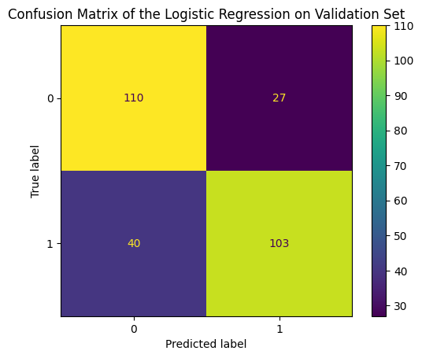

```python
bestlog_reg_model = search_results['LogisticRegression'].best_estimator_
bestlog_reg_model = Pipeline([
    ('preprocesser', preprocesser),
    ('model', LogisticRegression(random_state=random_state, max_iter=20000, C=bestlog_reg_model.named_steps['model'].C, class_weight=bestlog_reg_model.named_steps['model'].class_weight))
    ])

bestlog_reg_model.fit(x_tr, y_tr)
y_pred = bestlog_reg_model.predict(x_val)

print("Logistic Regression evaluation on validation set:")
print(f"Balanced Accuracy: {balanced_accuracy_score(y_val, y_pred):.4f}")

conf_matrix = ConfusionMatrixDisplay.from_estimator(bestlog_reg_model, x_val, y_val, display_labels=bestlog_reg_model.classes_, cmap='viridis')
plt.title("Confusion Matrix of the Logistic Regression on Validation Set")
plt.show()
```

```
SVM evaluation on validation set:
balanced accuracy: 0.7505
```

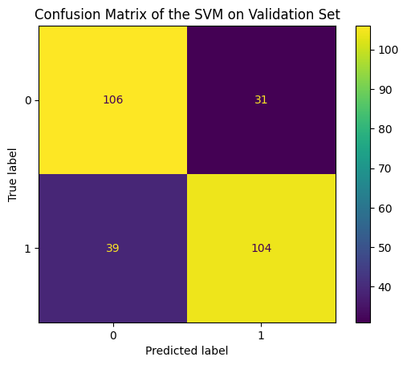

```
LinearSVC evaluation on validation set:
balanced accuracy: 0.7651
```

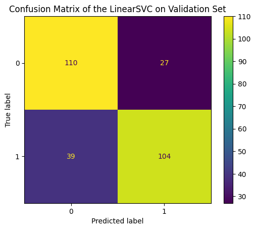

```python
best_svm_model = search_results['SVC'].best_estimator_
best_linearsvc_model = search_results['LinearSVC'].best_estimator_
best_svm_model = Pipeline([
    ('preprocesser', preprocesser),
    ('model', SVC(kernel='linear', random_state=random_state, C=best_svm_model.named_steps['model'].C, class_weight='balanced'))
])

best_linearsvc_model = Pipeline([
    ('preprocesser', preprocesser),
    ('model', LinearSVC(random_state=random_state, max_iter=20000, C=best_linearsvc_model.named_steps['model'].C, penalty='l2', dual=False, class_weight='balanced'))
])

best_svm_model.fit(x_tr, y_tr)
y_svm_pred = best_svm_model.predict(x_val)
print("SVM evaluation on validation set:")
print(f"balanced accuracy: {balanced_accuracy_score(y_val, y_svm_pred):.4f}")
ConfusionMatrixDisplay.from_estimator(best_svm_model, x_val, y_val, display_labels=best_svm_model.classes_, cmap='viridis')
plt.title("Confusion Matrix of the SVM on Validation Set")
plt.show()

best_linearsvc_model.fit(x_tr, y_tr)
y_linearsvc_pred = best_linearsvc_model.predict(x_val)
print("LinearSVC evaluation on validation set:")
print(f"balanced accuracy: {balanced_accuracy_score(y_val, y_linearsvc_pred):.4f}")
ConfusionMatrixDisplay.from_estimator(best_linearsvc_model, x_val, y_val, display_labels=best_linearsvc_model.classes_, cmap='viridis')
plt.title("Confusion Matrix of the LinearSVC on Validation Set")
plt.show()
```

All models perform similarly on the unseen data, good news. With LinearSVC performing slightly better than the others. Nonetheless I now include the ROC_AUC scores for Logistic Regression to cover all my bases.

```
Logistic Regression ROC AUC with probabilities: 0.8368
```

[figure not shown]

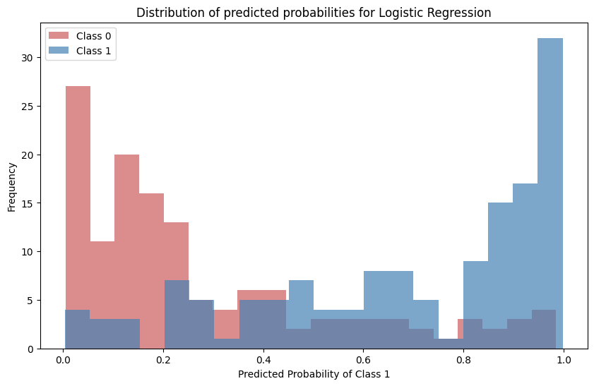

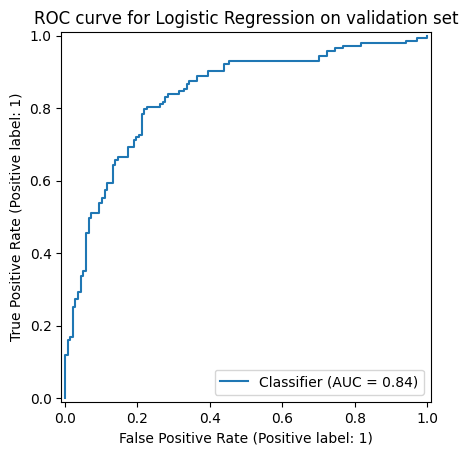

```python
y_log_proba = bestlog_reg_model.predict_proba(x_val)[:, 1]
print(f"Logistic Regression ROC AUC with probabilities: {roc_auc_score(y_val, y_log_proba):.4f}")

fig, axes = plt.subplots(1, 2, figsize=(20, 6))
plt.figure(figsize=(10, 6))
plt.hist(y_log_proba[y_val == 0], bins=20, alpha=0.7, label='Class 0', color='indianred')
plt.hist(y_log_proba[y_val == 1], bins=20, alpha=0.7, label='Class 1', color='steelblue')
plt.title('Distribution of predicted probabilities for Logistic Regression')
plt.xlabel('Predicted Probability of Class 1')
plt.ylabel('Frequency')
plt.legend()
plt.show()

RocCurveDisplay.from_predictions(y_val, y_log_proba)
plt.title("ROC curve for Logistic Regression on validation set")
plt.show()
```

### PCA SCORES

We now try to perform the analysis on the reduced dataset, which contains 7 numerical features (the ones necessary to explain 95% of variance) and two categorical features.

```python
pca_cols = [f"PC{i+1}" for i in range(x_num_pca.shape[1])]

x_pca_df = pd.DataFrame(
    x_num_pca,
    columns=pca_cols,
    index=x_train.index
)

x_pca_cat = pd.concat([x_pca_df, x_train[cat_cols]],axis=1) # we concatenate the PCA numerical components with the original categorical features

num_pca_preprocesser = Pipeline([
    ('num_preprocesser', num_preprocesser),
    ('pca', PCA(n_components=0.95, random_state=random_state))
])

pca_preprocesser = ColumnTransformer([
    ('num', num_pca_preprocesser, num_cols),
    ('cat', cat_preprocesser, cat_cols)
])
x_pca_cat.head()
```

|  | PC1 | PC2 | PC3 | PC4 | PC5 | PC6 | PC7 | categorical_feature_1 | categorical_feature_2 |
| --- | --- | --- | --- | --- | --- | --- | --- | --- | --- |
| 0 | 5.937349 | -3.081484 | 3.046518 | -0.711188 | -0.630098 | 1.020210 | -0.205387 | F | C |
| 1 | -5.703926 | -2.173680 | -1.089319 | 1.946461 | -0.044532 | 0.584485 | -0.505383 | E | A |
| 2 | -1.095615 | 0.681505 | 0.630946 | -0.537679 | -0.437568 | -0.017782 | 0.138875 | A | A |
| 3 | -3.712646 | -1.038568 | 1.254724 | 2.640167 | -0.446685 | -0.171908 | -0.705434 | A | A |
| 4 | -2.829024 | -2.497424 | -0.286902 | 0.703684 | 2.591134 | -0.327190 | -0.015392 | A | A |

```
Final evaluation results with PCA:
Balanced accuracy: 0.7611403195344801
```

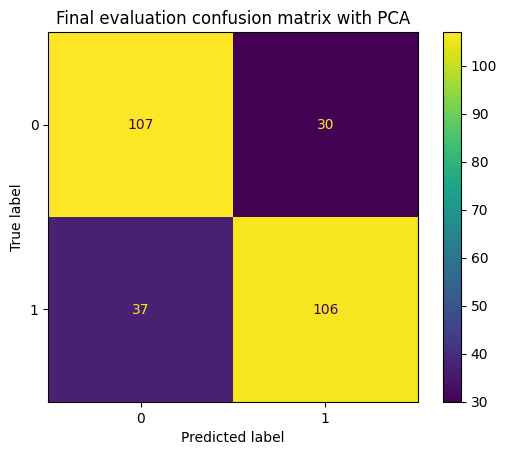

```python
pca_model = Pipeline([
    ('preprocesser', pca_preprocesser),
    ('model', LogisticRegression(
        random_state=random_state,
        max_iter=20000,
        C=15.85,
        class_weight='balanced'
    ))
])

pca_model.fit(x_tr, y_tr)
y_pca_pred = pca_model.predict(x_val)

print("Final evaluation results with PCA:")
print("Balanced accuracy:", balanced_accuracy_score(y_val, y_pca_pred))
print()
ConfusionMatrixDisplay.from_predictions(y_val, y_pca_pred)
plt.title("Final evaluation confusion matrix with PCA")
plt.show()
```

### LLM VERSION

After completing model selection and hyperparameter tuning, I trained the final model on the full labeled training dataset. This was done only after the validation and tuning process was complete. The reason for refitting on the full training data is that, once the best modeling strategy has been chosen, the model should use all available labeled examples to learn the final decision boundary.

The final fitted pipeline included all preprocessing steps and the tuned classifier. This means that the same operations used during cross-validation were also applied during final training and prediction. Numerical missing values were imputed, numerical features were scaled, categorical missing values were imputed, categorical features were one-hot encoded, and then the tuned classifier was applied.

Finally, the fitted model was used to generate predictions for the hidden test set. Since the hidden test set did not contain labels, it was not used for evaluation or model selection. It was only used at the final stage, after the model had already been chosen and trained. The output consisted of the test-set IDs together with the predicted class labels.

This final fitting strategy ensures that the hidden test predictions are produced by a model that was selected using a proper validation procedure, trained on all available labeled data, and applied consistently through a leakage-free preprocessing pipeline.

## SHAP VISUALIZATION

```python
try:
    import shap
    print("shap already installed")
except ImportError:
    %pip install shap
```

```
shap already installed
```

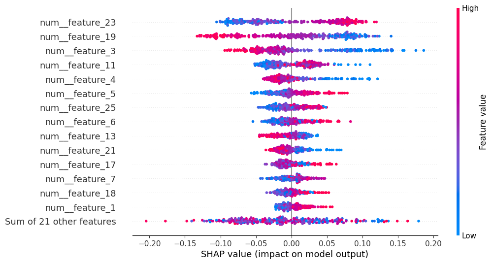

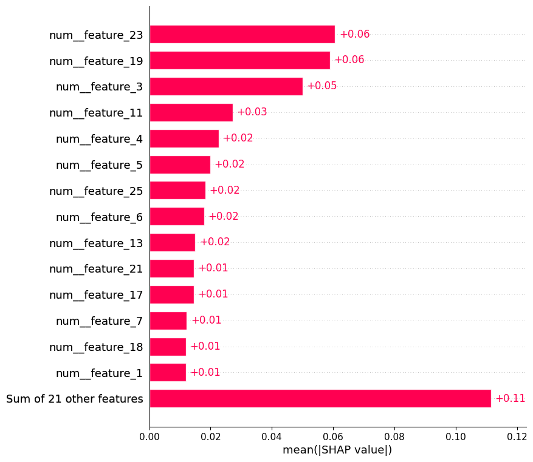

```python
rnd_forest.fit(x_tr, y_tr)


X_shap_transformed = rnd_forest.named_steps['preprocesser'].transform(x_val)
feature_names = rnd_forest.named_steps['preprocesser'].get_feature_names_out()

X_shap = pd.DataFrame(
    X_shap_transformed,
    columns=feature_names,
    index=x_val.index
)

rf_model = rnd_forest.named_steps['model']

explainer = shap.TreeExplainer(rf_model)

shap_values = explainer(X_shap)
shap_values_class1 = shap_values[:, :, 1]

shap.plots.beeswarm(shap_values_class1, max_display=15, plot_size=(10, 6))

shap.plots.bar(shap_values_class1, max_display=15)
```

The SHAP bar plot shows which variables have the largest average impact on the model prediction. The most relevant features are num__feature_23, num__feature_19 and num__feature_3, meaning that these are the variables the model relies on the most when separating the two classes. The beeswarm plot gives more detail on the direction of this effect. Positive SHAP values push the prediction towards label 1, while negative SHAP values push it towards label 0. The colour scale shows the feature value: blue means low values and pink means high values. From the beeswarm plot, num__feature_3 is particularly interesting: high values are mostly associated with negative SHAP values, so they push the model towards label 0, while low values are mostly associated with positive SHAP values, pushing the model towards label 1. This suggests that num__feature_3 is a useful indicator for the classification task. Moreover, the shap analysis in consistent with the mutual information one, as in both features 3, 19 and 23 were the most informative ones. In a real-world setting, if labels 0 and 1 represented loan rejection and loan approval, SHAP would help identify which features push the model towards one outcome or the other.For example, if num__feature_3 represented age, the model would be associating lower values of age with a higher probability of approval and higher values with a higher probability of rejection.

### LLM VERSION

//

### COMMENTS

Did not do this part.

## PREDICTIONS

```python
x_test = pd.read_csv('mldata_0003314701.TEST_FEATURES.csv')
bestlog_reg_model.fit(x_train, y_train)
y_test_pred = bestlog_reg_model.predict(x_test)

final_predictions = pd.DataFrame({
    'id': x_test['id'],
    'label': y_test_pred
})
final_predictions.to_csv('final_predictions.csv', index=False, header = False)
```

After having completed my notebook, I asked the LLM to compare the two notebooks. Here are the main differences he spotted:

1. *No discussion of selection bias.* The LLM proposes using the same CV for both hyperparameter search and final reporting, with no mention that the resulting "best score" is biased upward by selection-over-noise. *Nested cross-validation* (or at least repeated CV with reported standard deviations) is the literature-standard fix for honest performance estimates on small data, and the LLM does not raise it. With n = 1400 and ~50 candidate configurations, the reported CV score for the winning model is materially optimistic relative to true generalization.

3. *No critique of common defaults.* The LLM suggests  class_weight='balanced'  without checking the class distribution (mine is 51 / 49, essentially balanced — the reweighting is a no-op at best). It also suggests reporting ROC AUC without flagging that on hard-label predictions AUC collapses to balanced accuracy and is misleading. Both are common pitfalls and the LLM does not flag them.

## FINAL REMARKS AND LIMITATIONS

In conclusion, the analysis of this dataset is definitely affected by the anonimity of the features which definitely limited feature engineering and data preprocessing. This means that, even if the model can recognise useful statistical patterns, we cannot fully explain why those patterns exist or whether they make sense from a practical point of view. This also limits the interpretation of the SHAP results. The plots help us understand which features influence the model the most, but they cannot tell us whether these influences are reasonable, fair, or meaningful outside the dataset.

The LLM that was used for the audit is Chat GPT 5.5 (Edu licence)